# Final Project

Hwang Seong-Yun

2020 12 31

## 다음은 2018년 우리나라 시도별 산업별 종사자 수에 대한 통계청(KOSIS)의 자료이다. 다음 물음에 답하시오.

#### spot : 시도, industry : 산업, company : 사업체수(곳), worker : 종사자수(명), rate1 : 산업별 사업체수 비율(%), rate2 : 산업별 종사자 비율(%)

#### 산업별 사업체수 = (사업체수 / 시도별 총 사업체수)*100

#### 2018년 각 시도별 인구수는 20세부터 70세까지의 연령을 대상으로 산정하였음. (산업별 종사자 비율 = (종사자수 / 시도별 인구수)*100)

#### 변수 industry 관련

- a : 농업, 임업 및 어업
- b : 광업
- c : 제조업
- d : 전기, 가스, 증기 및 공기조절 공급업
- e : 수도, 하수 및 폐기물 처리, 원료 재생업
- f : 건설업
- g : 도매 및 소매업
- h : 운수 및 창고업
- i : 숙박 및 음식점업
- j : 정보통신업
- k : 금융 및 보험업
- l : 부동산업
- m : 전문, 과학 및 기술 서비스업
- n : 사업시설 관리, 사업지원 및 임대 서비스업
- o : 공공행정, 국방 및 사회보장 행정
- p : 교육 서비스업
- q : 보건업 및 사회복지서비스업
- r : 예술, 스포츠 및 여가관련 서비스업
- s : 협회 및 단체, 수리 및 기타 개인 서비스업

```r
library(tidyverse)
library(nFactors)
library(psych)
```

```r
library(ggplot2)
final <- read.csv("C:/Users/HSY/Desktop/final.csv",sep=",",header=T)
final
```

```
##          spot industry company  worker        rate1    rate2
## 1       Seoul        a      30     462  0.003643496  0.00627
## 2       Seoul        b      24      81  0.002914797  0.00110
## 3       Seoul        c   58970  266500  7.161898747  3.62000
## 4       Seoul        d     183    6083  0.022225326  0.08260
## 5       Seoul        e     451    9139  0.054773891  0.12400
## 6       Seoul        f   21825  379353  2.650643381  5.15000
## 7       Seoul        g  223955  896326 27.199305310 12.20000
## 8       Seoul        h   95412  272618 11.587774860  3.70000
## 9       Seoul        i  130595  495092 15.860745580  6.72000
## 10      Seoul        j   23384  357761  2.839983726  4.86000
## 11      Seoul        k   11220  262273  1.362667525  3.56000
## 12      Seoul        l   41282  158063  5.013693473  2.15000
## 13      Seoul        m   41654  463519  5.058872824  6.29000
## 14      Seoul        n   16198  496433  1.967244970  6.74000
```

[output cut: 309 more lines]

### reference : https://statkclee.github.io/statistics/stat-exploratory-factor-analysis.html

### (1) 산업별 종사자 비율에 의해 각 시도를 요인분석을 통해 분류하시오.

### (2) 요인분석을 한 후 요인에 적절한 이름을 부여하시오.

### (3) 요인분석 후 인자회전을 시키시오.

- 총 17곳으로 분류된 시도를 기준으로 변수 company, rate2를 바탕으로 요인분석 실시, varimax rotate 적용

### 서울

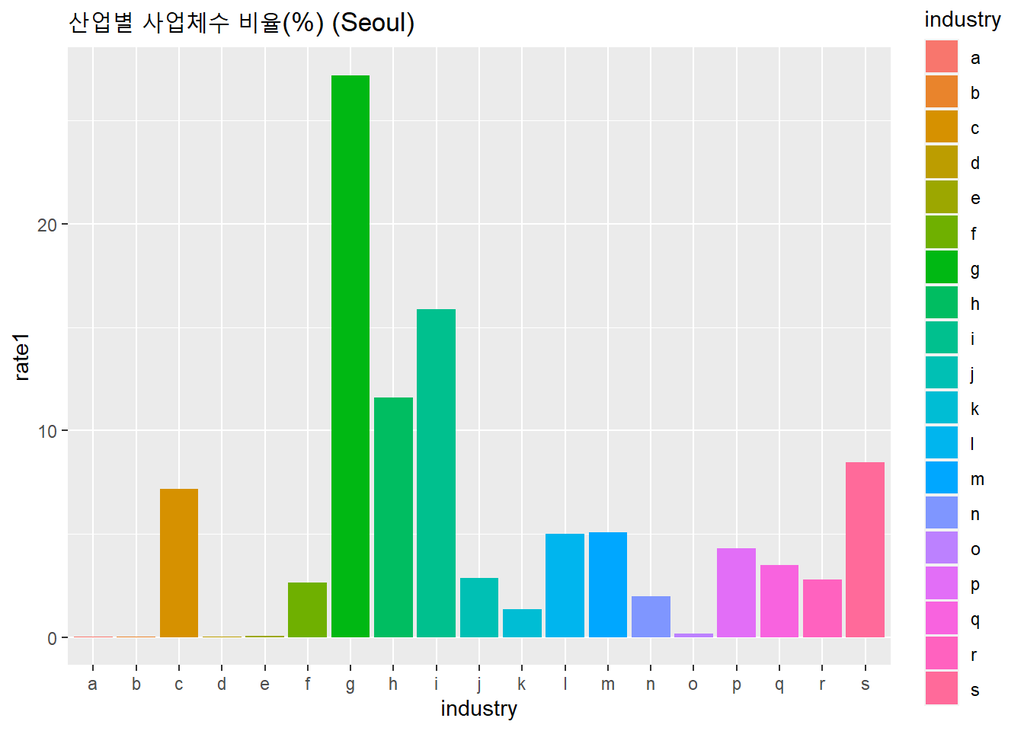

```r
Seoul <- final[final$spot=="Seoul",c(2,3,4,5,6)]
ggplot(Seoul, aes(x=industry, y=rate1, fill=industry)) +
   geom_bar(stat="identity") +
   ggtitle("산업별 사업체수 비율(%) (Seoul)")
```

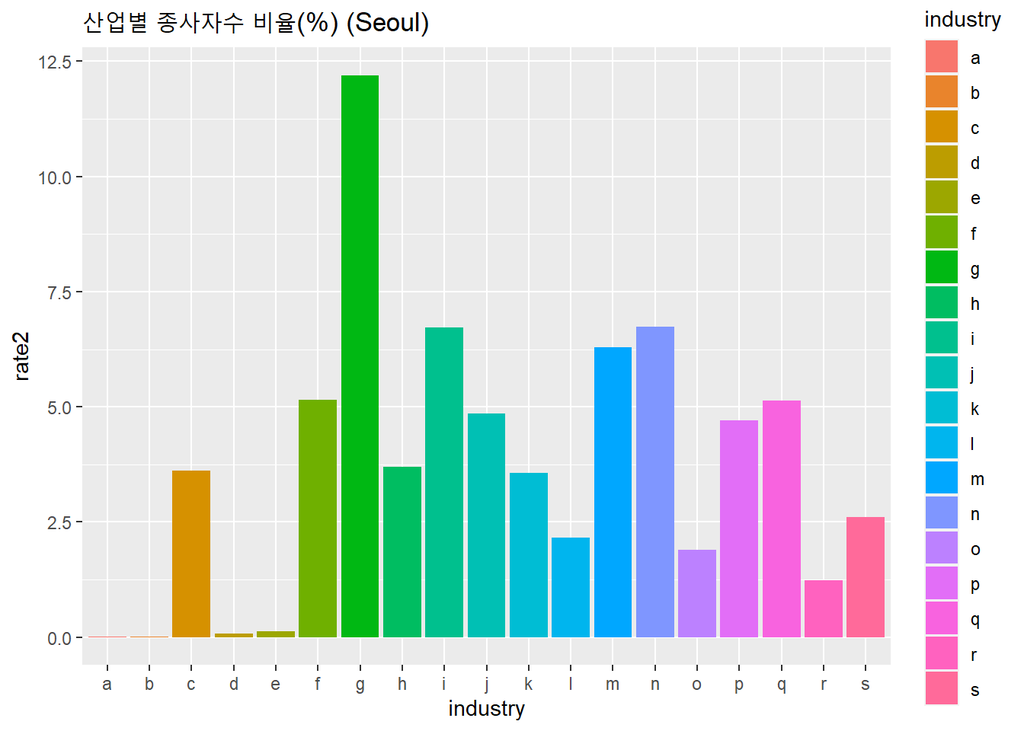

```r
ggplot(Seoul, aes(x=industry, y=rate2, fill=industry)) +
   geom_bar(stat="identity") +
   ggtitle("산업별 종사자수 비율(%) (Seoul)")
```

#### 서울의 경우 도매 및 소매업의 비중이 가장 큼.

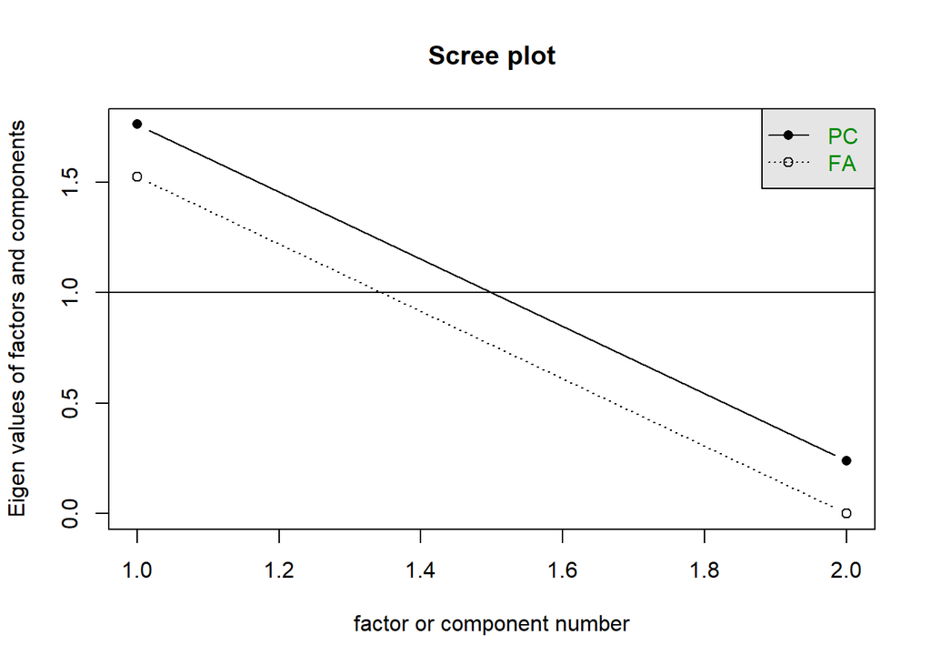

```r
# 요인수 결정
Seoul <- final[final$spot=="Seoul",c(3,6)]
Seoul_cor <- cor(Seoul, use = "pairwise.complete.obs")
scree(Seoul_cor, factors = TRUE)
```

#### scree plot을 통해 요인수를 1로 결정

```r
Seoul_fa <- fa(Seoul, nfactors=1, n.obs=N, rotate="varimax")
print(Seoul_fa$loadings, cutoff = 0.2)
```

```
##
## Loadings:
##         MR1
## company 0.873
## rate2   0.873
##
##                  MR1
## SS loadings    1.525
## Proportion Var 0.763
```

```r
colnames(Seoul_fa$loadings) <- c("Factor1")
fa.diagram(Seoul_fa)
```

[output not shown]

#### 서울의 경우 다음과 같은 요인분석 결과를 얻는다.

- $ company = 0.873 * Factor1 $
- $ rate2 = 0.873 * Factor1 $
- Factor1은 서울의 산업별 사업체수 및 종사자 비율과 관련한 잠재요인으로 보여진다.

### 부산

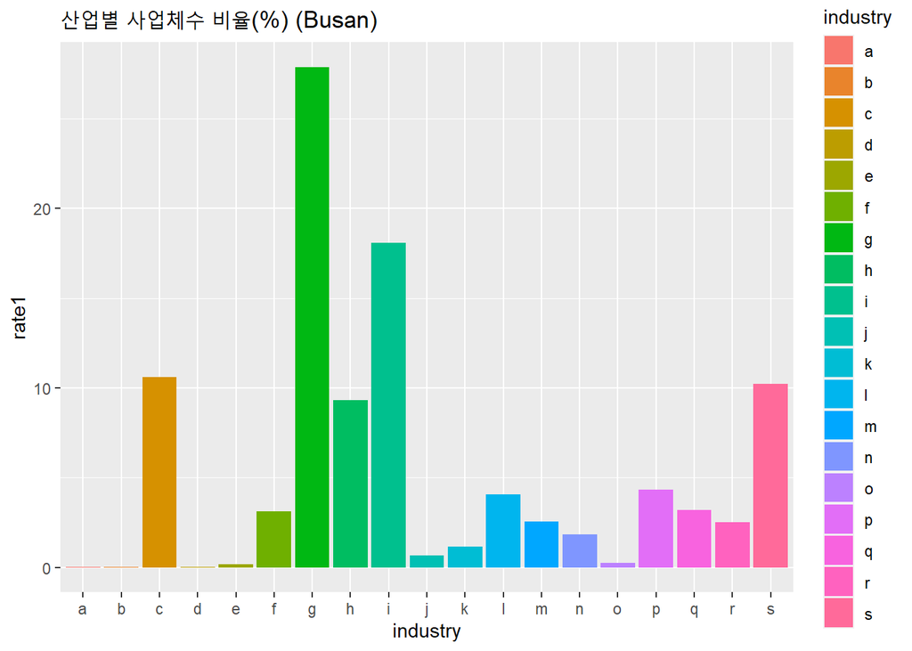

```r
Busan <- final[final$spot=="Busan",c(2,3,4,5,6)]
ggplot(Busan, aes(x=industry, y=rate1, fill=industry)) +
   geom_bar(stat="identity") +
   ggtitle("산업별 사업체수 비율(%) (Busan)")
```

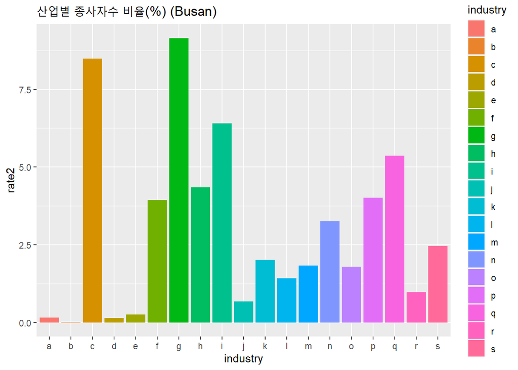

```r
ggplot(Busan, aes(x=industry, y=rate2, fill=industry)) +
   geom_bar(stat="identity") +
   ggtitle("산업별 종사자수 비율(%) (Busan)")
```

#### 부산의 경우 사업체수는 도매 및 소매업이 1위, 숙박 및 음식점업이 2위를 기록한 반면에, 종사자 비율은 도매 및 소매업이 1위, 제조업이 2위를 기록함.

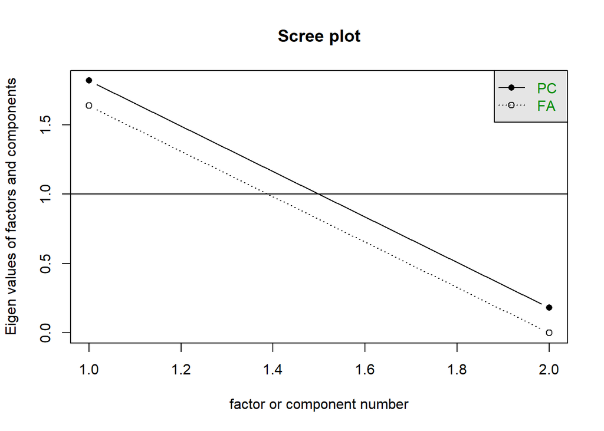

```r
# 요인수 결정
Busan <- final[final$spot=="Busan",c(3,6)]
Busan_cor <- cor(Busan, use = "pairwise.complete.obs")
scree(Busan_cor, factors = TRUE)
```

#### scree plot을 통해 요인수를 1로 결정

```r
Busan_fa <- fa(Busan, nfactors=1, n.obs=N, rotate="varimax")
print(Busan_fa$loadings, cutoff = 0.2)
```

```
##
## Loadings:
##         MR1
## company 0.905
## rate2   0.905
##
##                  MR1
## SS loadings    1.639
## Proportion Var 0.820
```

```r
colnames(Busan_fa$loadings) <- c("Factor1")
fa.diagram(Busan_fa)
```

[output not shown]

#### 부산의 경우 다음과 같은 요인분석 결과를 얻는다.

- $ company = 0.905 * Factor1 $
- $ rate2 = 0.905 * Factor1 $
- Factor1은 부산의 산업별 사업체수 및 종사자 비율과 관련한 잠재요인으로 보여진다.

### 대구

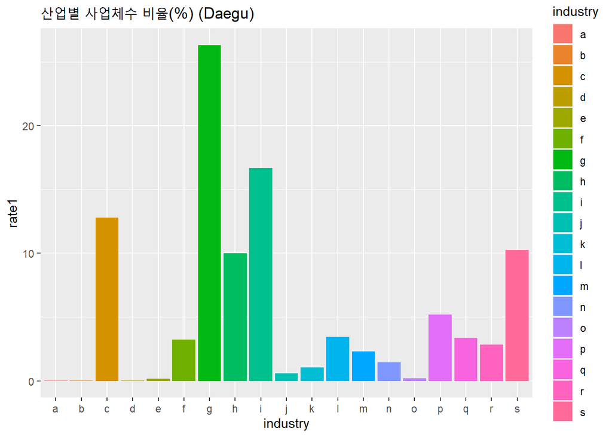

```r
Daegu <- final[final$spot=="Daegu",c(2,3,4,5,6)]
ggplot(Daegu, aes(x=industry, y=rate1, fill=industry)) +
   geom_bar(stat="identity") +
   ggtitle("산업별 사업체수 비율(%) (Daegu)")
```

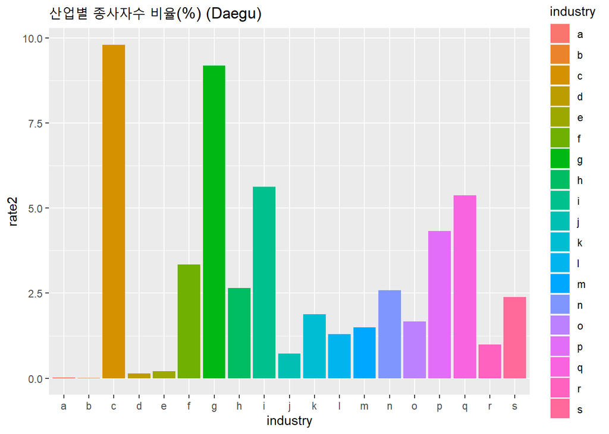

```r
ggplot(Daegu, aes(x=industry, y=rate2, fill=industry)) +
   geom_bar(stat="identity") +
   ggtitle("산업별 종사자수 비율(%) (Daegu)")
```

#### 대구의 경우 사업체수는 도매 및 소매업이 1위, 숙박 및 음식점업이 2위를 기록한 반면에, 종사자 비율은 제조업이 1위, 도매 및 소매업이 2위를 기록함.

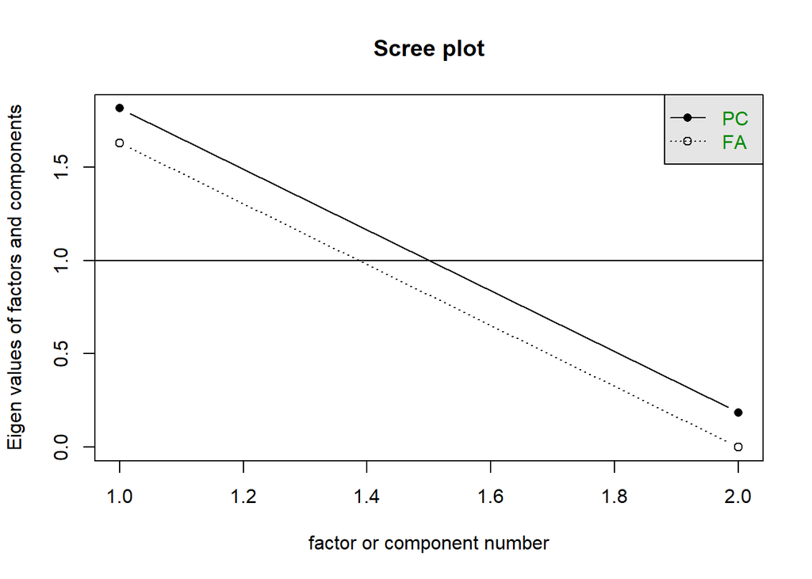

```r
# 요인수 결정
Daegu <- final[final$spot=="Daegu",c(3,6)]
Daegu_cor <- cor(Daegu, use = "pairwise.complete.obs")
scree(Daegu_cor, factors = TRUE)
```

#### scree plot을 통해 요인수를 1로 결정

```r
Daegu_fa <- fa(Daegu, nfactors=1, n.obs=N, rotate="varimax")
print(Daegu_fa$loadings, cutoff = 0.2)
```

```
##
## Loadings:
##         MR1
## company 0.902
## rate2   0.902
##
##                  MR1
## SS loadings    1.629
## Proportion Var 0.814
```

```r
colnames(Daegu_fa$loadings) <- c("Factor1")
fa.diagram(Daegu_fa)
```

[output not shown]

#### 대구의 경우 다음과 같은 요인분석 결과를 얻는다.

- $ company = 0.902 * Factor1 $
- $ rate2 = 0.902 * Factor1 $
- Factor1은 대구의 산업별 사업체수 및 종사자 비율과 관련한 잠재요인으로 보여진다.

### 인천

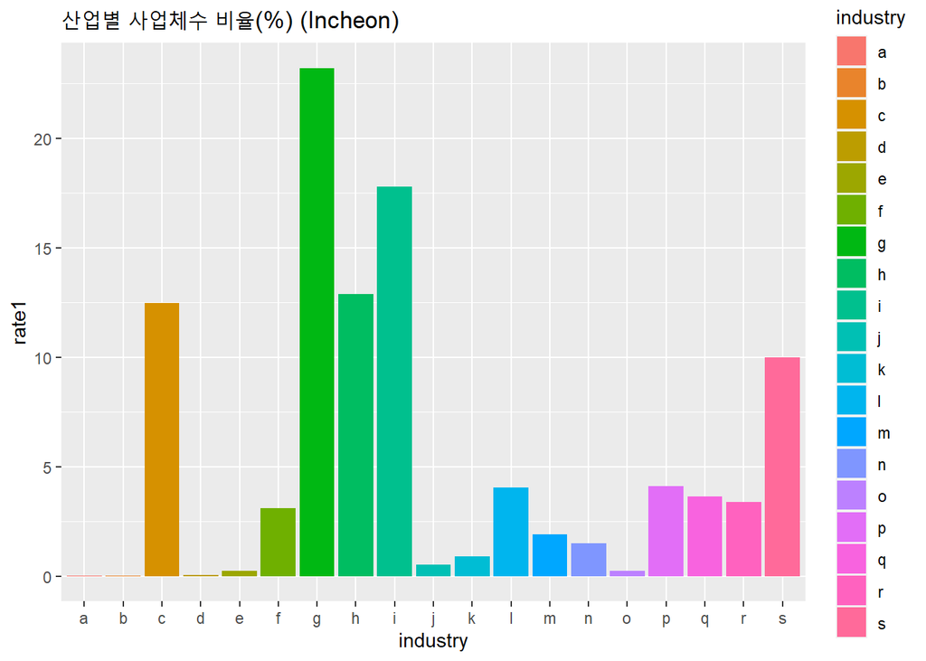

```r
Incheon <- final[final$spot=="Incheon",c(2,3,4,5,6)]
ggplot(Incheon, aes(x=industry, y=rate1, fill=industry)) +
   geom_bar(stat="identity") +
   ggtitle("산업별 사업체수 비율(%) (Incheon)")
```

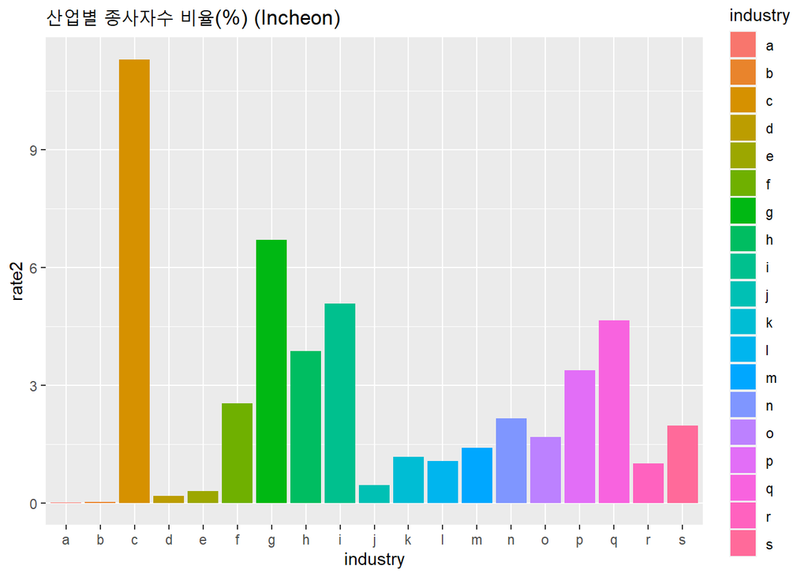

```r
ggplot(Incheon, aes(x=industry, y=rate2, fill=industry)) +
   geom_bar(stat="identity") +
   ggtitle("산업별 종사자수 비율(%) (Incheon)")
```

#### 인천의 경우 사업체수는 도매 및 소매업이 1위, 숙박 및 음식점업이 2위를 기록한 반면에, 종사자 비율은 제조업이 압도적으로 큼.

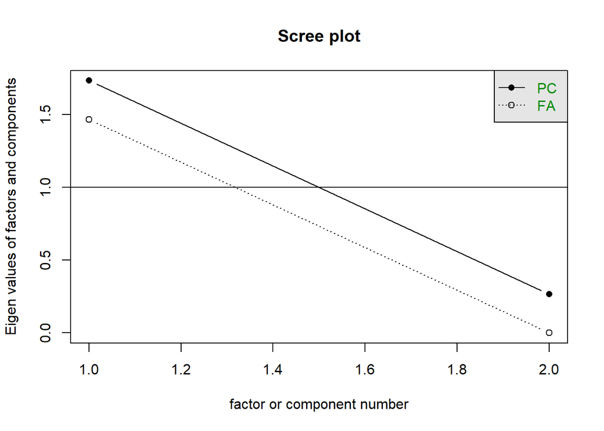

```r
# 요인수 결정
Incheon <- final[final$spot=="Incheon",c(3,6)]
Incheon_cor <- cor(Incheon, use = "pairwise.complete.obs")
scree(Incheon_cor, factors = TRUE)
```

#### scree plot을 통해 요인수를 1로 결정

```r
Incheon_fa <- fa(Incheon, nfactors=1, n.obs=N, rotate="varimax")
print(Incheon_fa$loadings, cutoff = 0.2)
```

```
##
## Loadings:
##         MR1
## company 0.857
## rate2   0.857
##
##                  MR1
## SS loadings    1.467
## Proportion Var 0.734
```

```r
colnames(Incheon_fa$loadings) <- c("Factor1")
fa.diagram(Incheon_fa)
```

[output not shown]

#### 인천의 경우 다음과 같은 요인분석 결과를 얻는다.

- $ company = 0.857 * Factor1 $
- $ rate2 = 0.857 * Factor1 $
- Factor1은 인천의 산업별 사업체수 및 종사자 비율과 관련한 잠재요인으로 보여진다.

### 광주

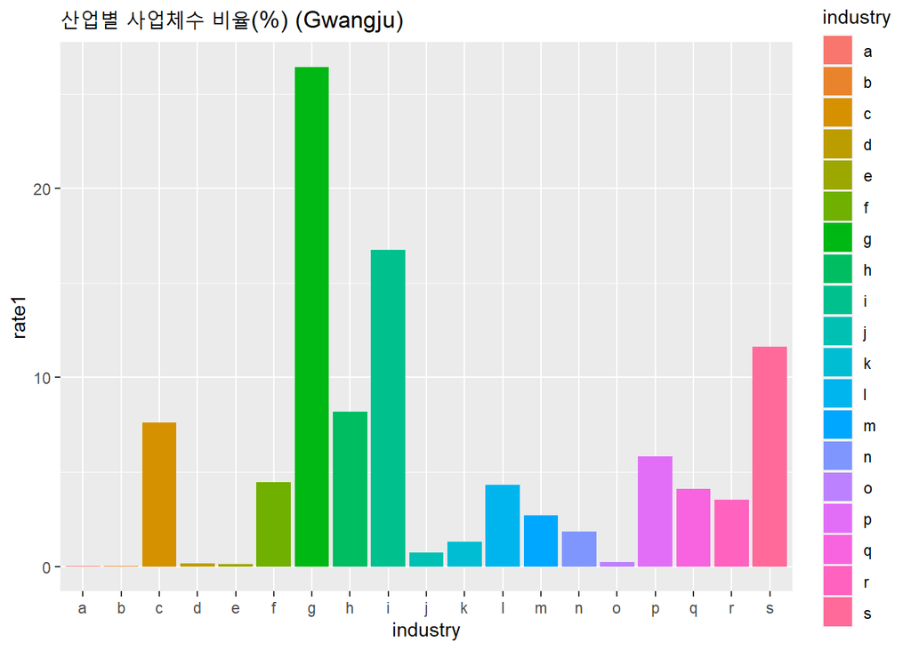

```r
Gwangju <- final[final$spot=="Gwangju",c(2,3,4,5,6)]
ggplot(Gwangju, aes(x=industry, y=rate1, fill=industry)) +
   geom_bar(stat="identity") +
   ggtitle("산업별 사업체수 비율(%) (Gwangju)")
```

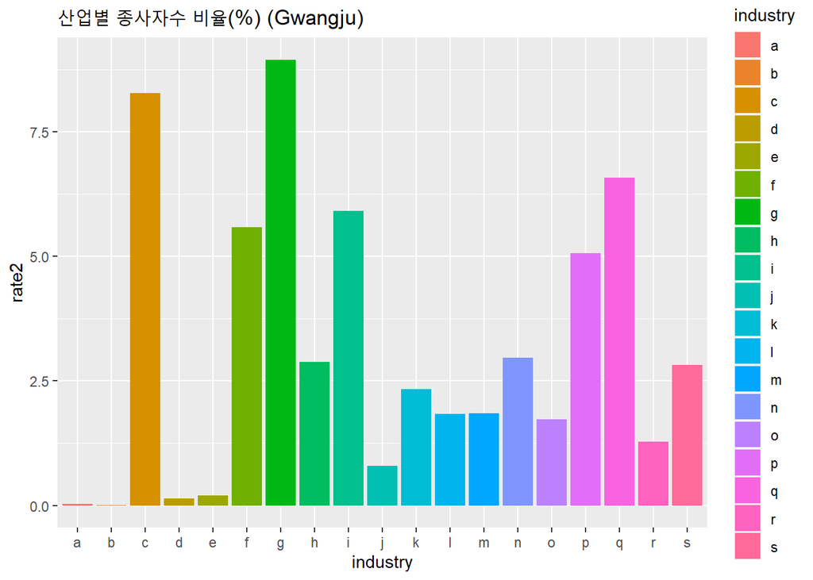

```r
ggplot(Gwangju, aes(x=industry, y=rate2, fill=industry)) +
   geom_bar(stat="identity") +
   ggtitle("산업별 종사자수 비율(%) (Gwangju)")
```

#### 광주의 경우 사업체수는 도매 및 소매업이 1위, 숙박 및 음식점업이 2위를 기록한 반면에, 종사자 비율은 도매 및 소매업이 1위, 제조업이 2위를 기록함.

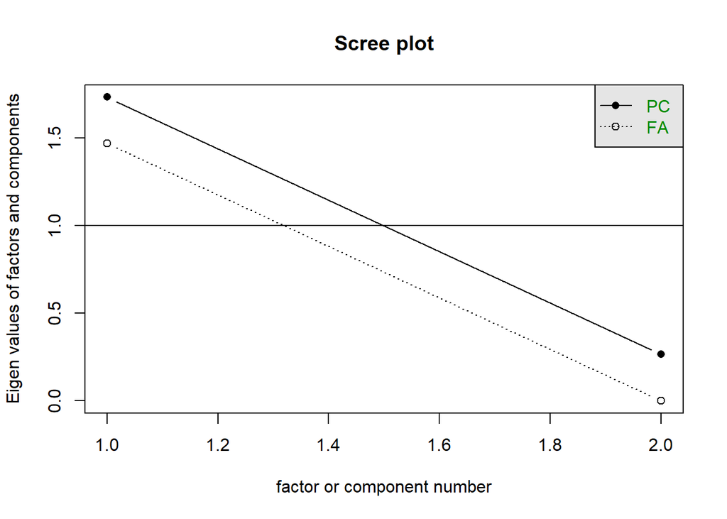

```r
# 요인수 결정
Gwangju <- final[final$spot=="Gwangju",c(3,6)]
Gwangju_cor <- cor(Gwangju, use = "pairwise.complete.obs")
scree(Gwangju_cor, factors = TRUE)
```

#### scree plot을 통해 요인수를 1로 결정

```r
Gwangju_fa <- fa(Gwangju, nfactors=1, n.obs=N, rotate="varimax")
print(Gwangju_fa$loadings, cutoff = 0.2)
```

```
##
## Loadings:
##         MR1
## company 0.857
## rate2   0.857
##
##                  MR1
## SS loadings    1.469
## Proportion Var 0.735
```

```r
colnames(Gwangju_fa$loadings) <- c("Factor1")
fa.diagram(Gwangju_fa)
```

[output not shown]

#### 광주의 경우 다음과 같은 요인분석 결과를 얻는다.

- $ company = 0.857 * Factor1 $
- $ rate2 = 0.857 * Factor1 $
- Factor1은 광주의 산업별 사업체수 및 종사자 비율과 관련한 잠재요인으로 보여진다.

### 대전

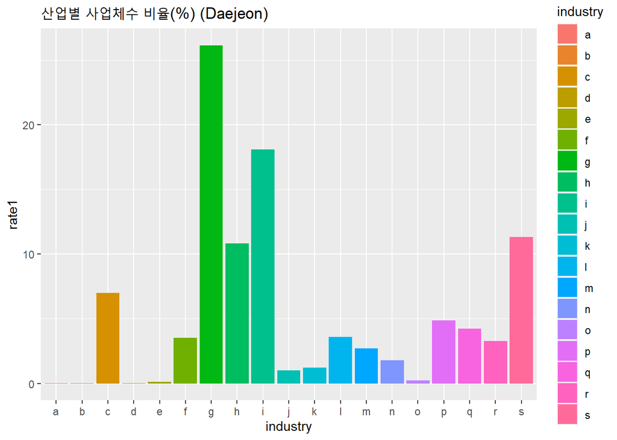

```r
Daejeon <- final[final$spot=="Daejeon",c(2,3,4,5,6)]
ggplot(Daejeon, aes(x=industry, y=rate1, fill=industry)) +
   geom_bar(stat="identity") +
   ggtitle("산업별 사업체수 비율(%) (Daejeon)")
```

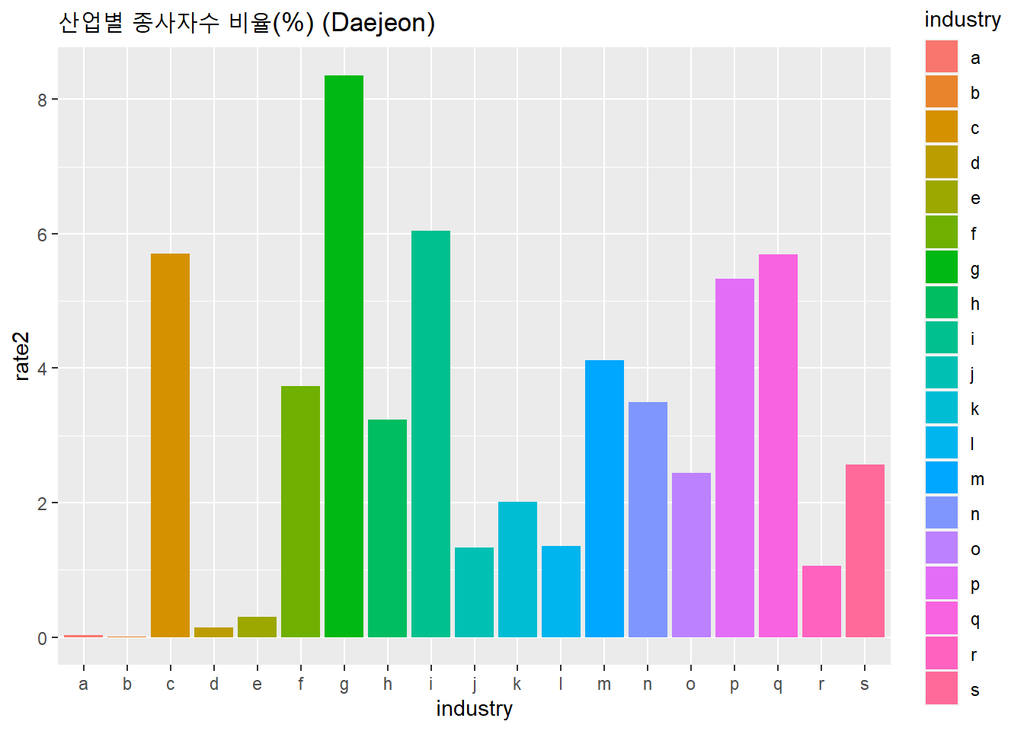

```r
ggplot(Daejeon, aes(x=industry, y=rate2, fill=industry)) +
   geom_bar(stat="identity") +
   ggtitle("산업별 종사자수 비율(%) (Daejeon)")
```

#### 대전의 경우 도매 및 소매업이 1위, 숙박 및 음식점업이 2위를 기록함.

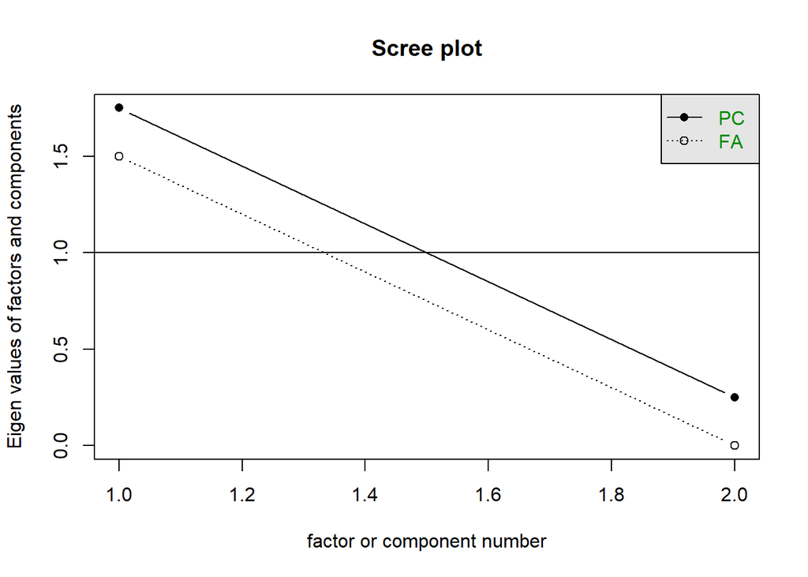

```r
# 요인수 결정
Daejeon <- final[final$spot=="Daejeon",c(3,6)]
Daejeon_cor <- cor(Daejeon, use = "pairwise.complete.obs")
scree(Daejeon_cor, factors = TRUE)
```

#### scree plot을 통해 요인수를 1로 결정

```r
Daejeon_fa <- fa(Daejeon, nfactors=1, n.obs=N, rotate="varimax")
print(Daejeon_fa$loadings, cutoff = 0.2)
```

```
##
## Loadings:
##         MR1
## company 0.866
## rate2   0.866
##
##                  MR1
## SS loadings    1.499
## Proportion Var 0.749
```

```r
colnames(Daejeon_fa$loadings) <- c("Factor1")
fa.diagram(Daejeon_fa)
```

[output not shown]

#### 대전의 경우 다음과 같은 요인분석 결과를 얻는다.

- $ company = 0.866 * Factor1 $
- $ rate2 = 0.866 * Factor1 $
- Factor1은 대전의 산업별 사업체수 및 종사자 비율과 관련한 잠재요인으로 보여진다.

### 울산

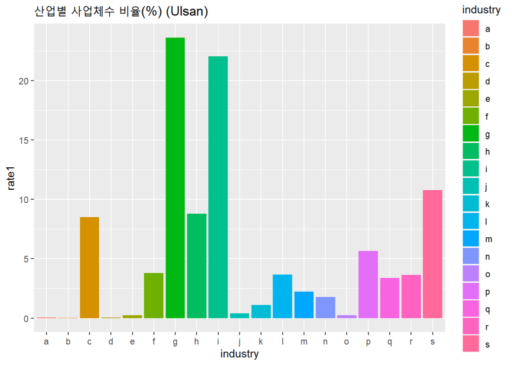

```r
Ulsan <- final[final$spot=="Ulsan",c(2,3,4,5,6)]
ggplot(Ulsan, aes(x=industry, y=rate1, fill=industry)) +
   geom_bar(stat="identity") +
   ggtitle("산업별 사업체수 비율(%) (Ulsan)")
```

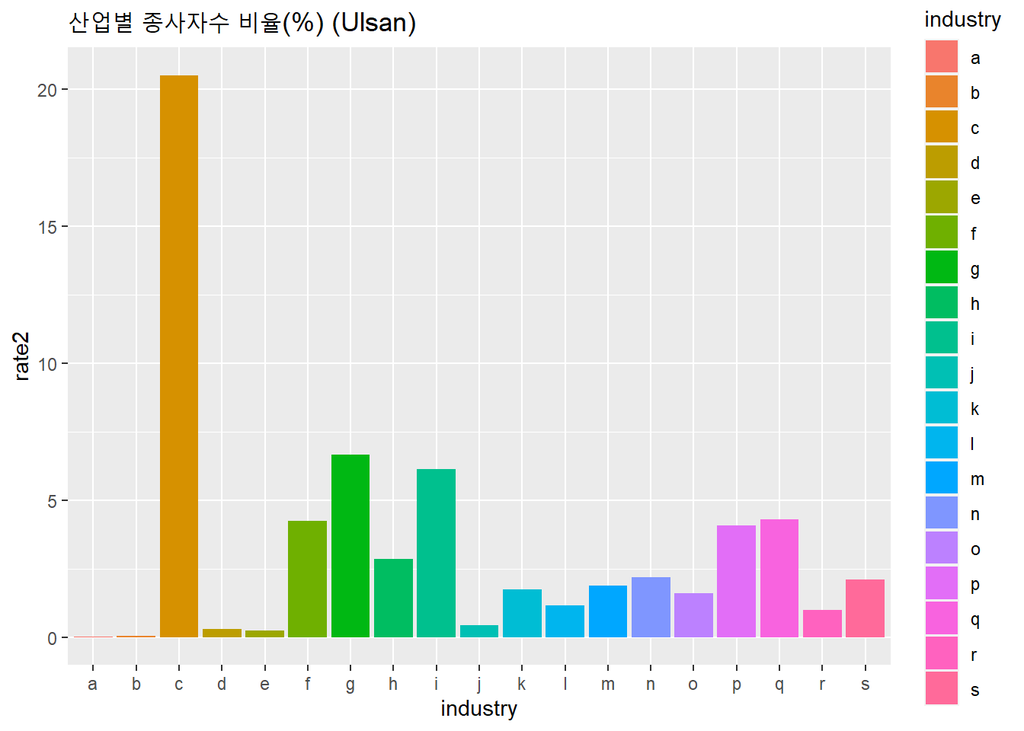

```r
ggplot(Ulsan, aes(x=industry, y=rate2, fill=industry)) +
   geom_bar(stat="identity") +
   ggtitle("산업별 종사자수 비율(%) (Ulsan)")
```

#### 울산의 경우 사업체수는 도매 및 소매업이 1위, 숙박 및 음식점업이 2위를 기록한 반면에, 종사자 비율은 제조업이 압도적으로 큼.

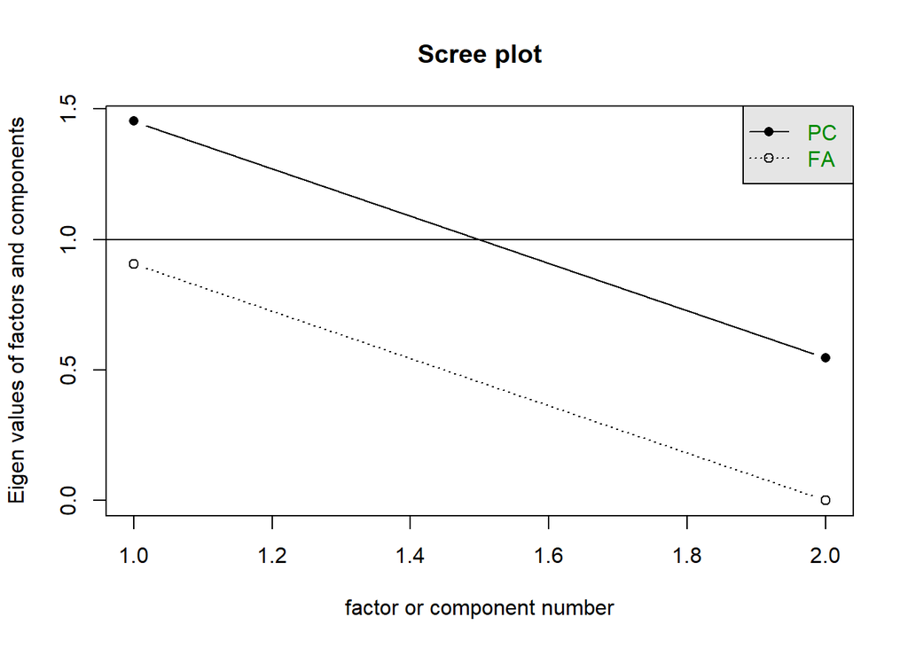

```r
# 요인수 결정
Ulsan <- final[final$spot=="Ulsan",c(3,6)]
Ulsan_cor <- cor(Ulsan, use = "pairwise.complete.obs")
scree(Ulsan_cor, factors = TRUE)
```

#### scree plot을 통해 요인수를 1로 결정

```r
Ulsan_fa <- fa(Ulsan, nfactors=1, n.obs=N, rotate="varimax")
print(Ulsan_fa$loadings, cutoff = 0.2)
```

```
##
## Loadings:
##         MR1
## company 0.673
## rate2   0.673
##
##                  MR1
## SS loadings    0.907
## Proportion Var 0.453
```

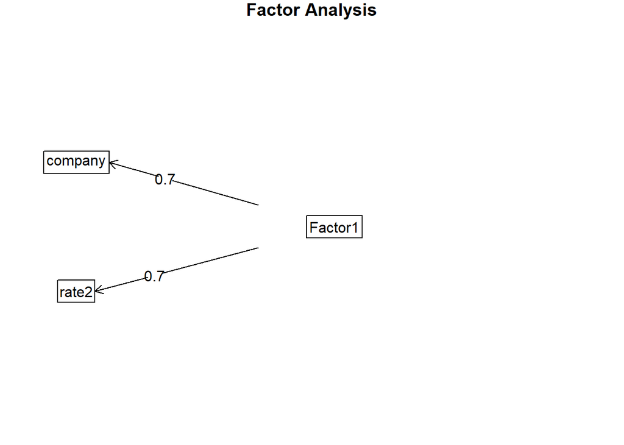

```r
colnames(Ulsan_fa$loadings) <- c("Factor1")
fa.diagram(Ulsan_fa)
```

#### 울산의 경우 다음과 같은 요인분석 결과를 얻는다.

- $ company = 0.673 * Factor1 $
- $ rate2 = 0.673 * Factor1 $
- Factor1은 울산의 산업별 사업체수 및 종사자 비율과 관련한 잠재요인으로 보여진다.

### 세종

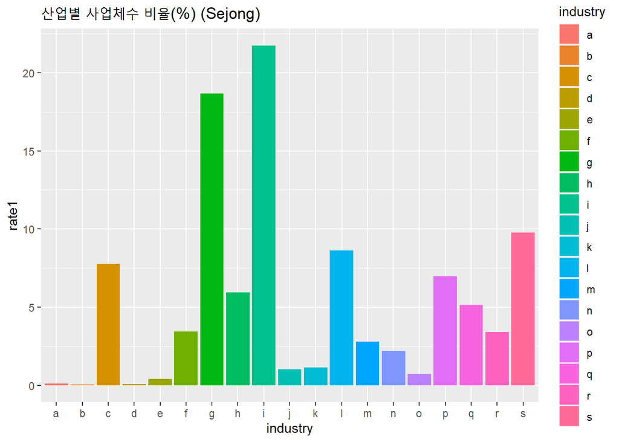

```r
Sejong <- final[final$spot=="Sejong",c(2,3,4,5,6)]
ggplot(Sejong, aes(x=industry, y=rate1, fill=industry)) +
   geom_bar(stat="identity") +
   ggtitle("산업별 사업체수 비율(%) (Sejong)")
```

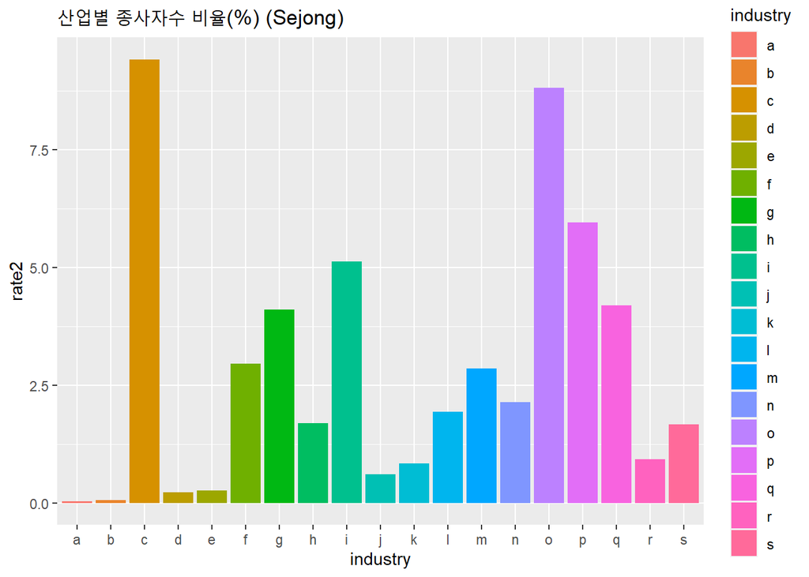

```r
ggplot(Sejong, aes(x=industry, y=rate2, fill=industry)) +
   geom_bar(stat="identity") +
   ggtitle("산업별 종사자수 비율(%) (Sejong)")
```

#### 세종의 경우 사업체수는 숙박 및 음식점업이 1위, 도매 및 소매업이 2위를 기록한 반면에, 종사자 비율은 제조업이 1위, 공공행정, 국방 및 사회보장 행정이 2위를 기록함.

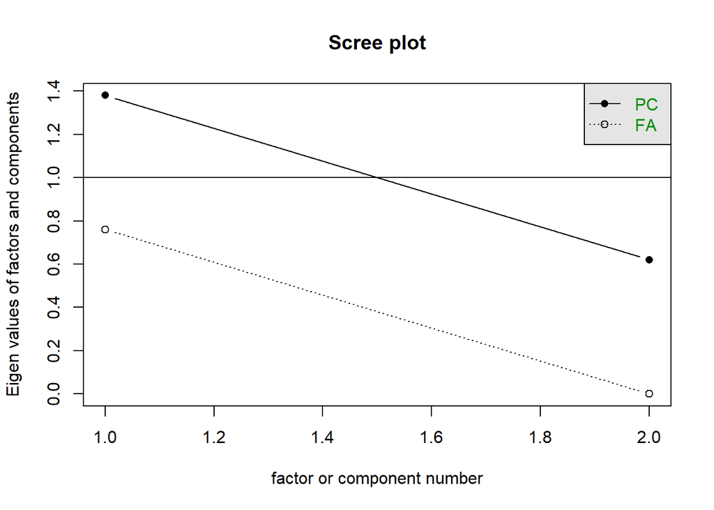

```r
# 요인수 결정
Sejong <- final[final$spot=="Sejong",c(3,6)]
Sejong_cor <- cor(Sejong, use = "pairwise.complete.obs")
scree(Sejong_cor, factors = TRUE)
```

#### scree plot을 통해 요인수를 1로 결정

```r
Sejong_fa <- fa(Sejong, nfactors=1, n.obs=N, rotate="varimax")
print(Sejong_fa$loadings, cutoff = 0.2)
```

```
##
## Loadings:
##         MR1
## company 0.617
## rate2   0.617
##
##                  MR1
## SS loadings    0.761
## Proportion Var 0.380
```

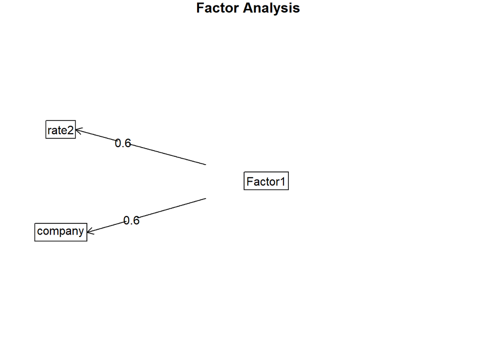

```r
colnames(Sejong_fa$loadings) <- c("Factor1")
fa.diagram(Sejong_fa)
```

#### 세종의 경우 다음과 같은 요인분석 결과를 얻는다.

- $ company = 0.617 * Factor1 $
- $ rate2 = 0.617 * Factor1 $
- Factor1은 세종의 산업별 사업체수 및 종사자 비율과 관련한 잠재요인으로 보여진다.

### 경기도

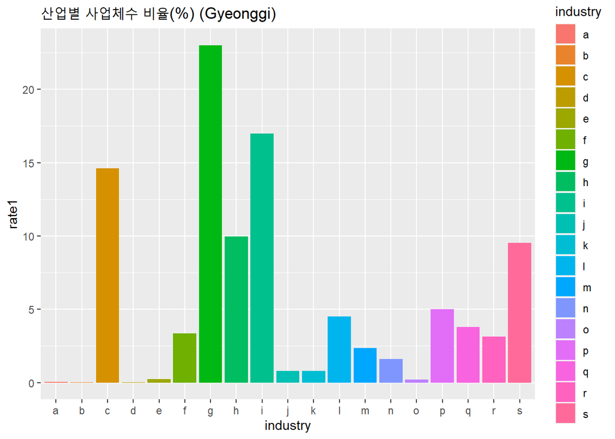

```r
Gyeonggi <- final[final$spot=="Gyeonggi",c(2,3,4,5,6)]
ggplot(Gyeonggi, aes(x=industry, y=rate1, fill=industry)) +
   geom_bar(stat="identity") +
   ggtitle("산업별 사업체수 비율(%) (Gyeonggi)")
```

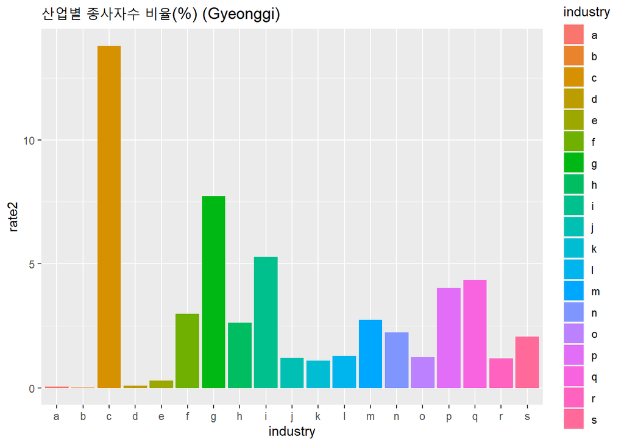

```r
ggplot(Gyeonggi, aes(x=industry, y=rate2, fill=industry)) +
   geom_bar(stat="identity") +
   ggtitle("산업별 종사자수 비율(%) (Gyeonggi)")
```

#### 경기도의 경우 사업체수는 도매 및 소매업이 1위, 숙박 및 음식점업이 2위를 기록한 반면에, 종사자 비율은 제조업이 압도적으로 큼.

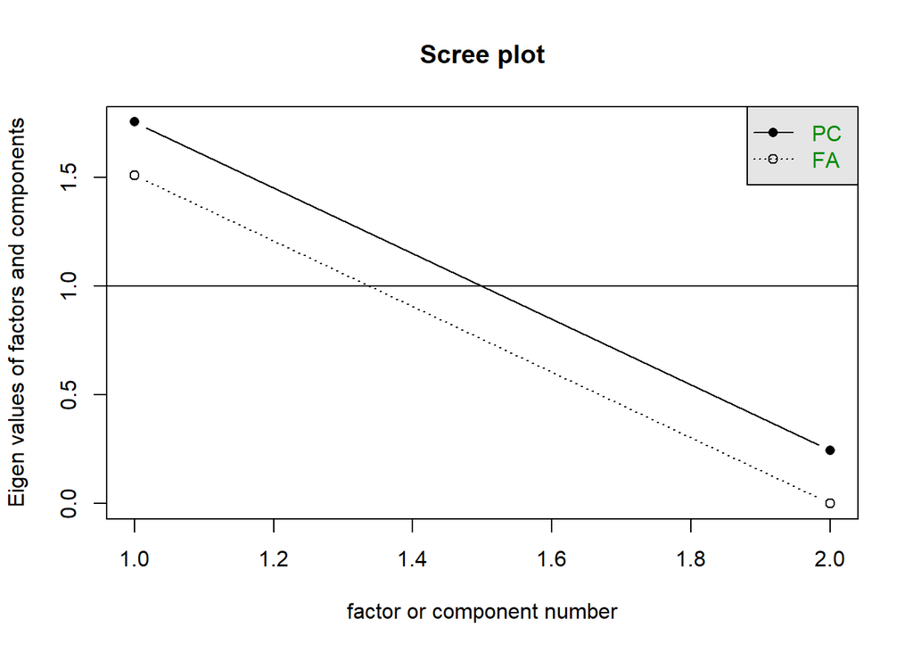

```r
# 요인수 결정
Gyeonggi <- final[final$spot=="Gyeonggi",c(3,6)]
Gyeonggi_cor <- cor(Gyeonggi, use = "pairwise.complete.obs")
scree(Gyeonggi_cor, factors = TRUE)
```

#### scree plot을 통해 요인수를 1로 결정

```r
Gyeonggi_fa <- fa(Gyeonggi, nfactors=1, n.obs=N, rotate="varimax")
print(Gyeonggi_fa$loadings, cutoff = 0.2)
```

```
##
## Loadings:
##         MR1
## company 0.869
## rate2   0.869
##
##                  MR1
## SS loadings    1.510
## Proportion Var 0.755
```

```r
colnames(Gyeonggi_fa$loadings) <- c("Factor1")
fa.diagram(Gyeonggi_fa)
```

[output not shown]

### 강원도

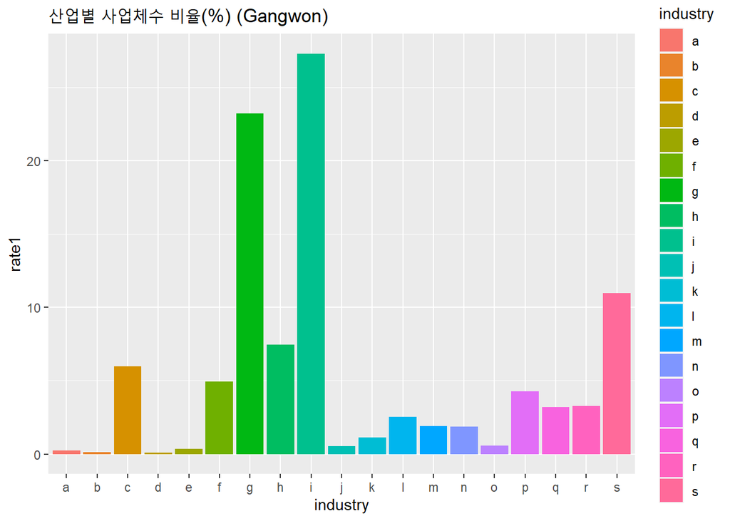

```r
Gangwon <- final[final$spot=="Gangwon",c(2,3,4,5,6)]
ggplot(Gangwon, aes(x=industry, y=rate1, fill=industry)) +
   geom_bar(stat="identity") +
   ggtitle("산업별 사업체수 비율(%) (Gangwon)")
```

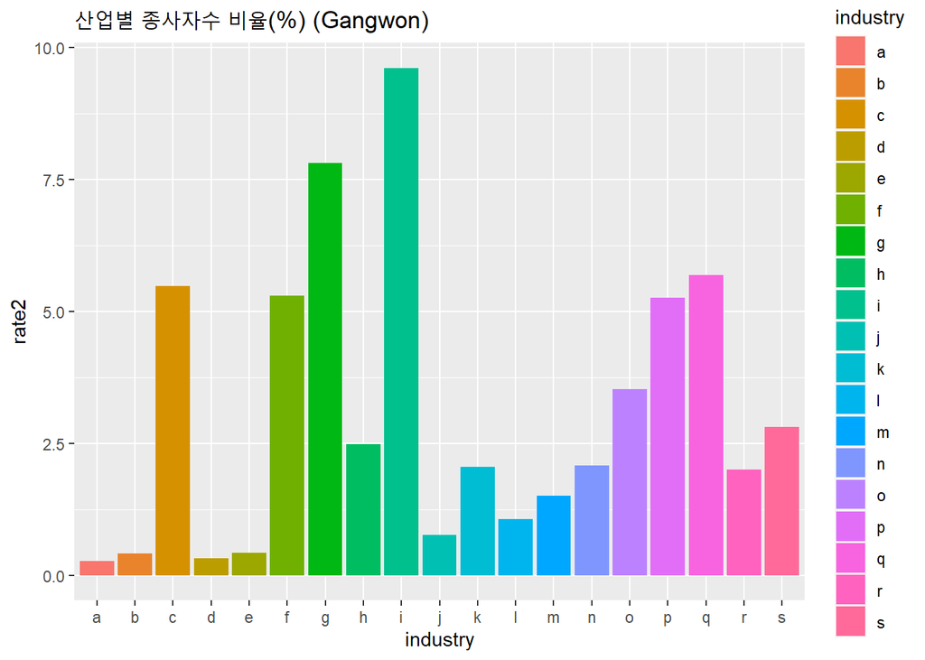

```r
ggplot(Gangwon, aes(x=industry, y=rate2, fill=industry)) +
   geom_bar(stat="identity") +
   ggtitle("산업별 종사자수 비율(%) (Gangwon)")
```

#### 강원도의 경우 숙박 및 음식점업이 1위, 도매 및 소매업이 2위를 기록함.

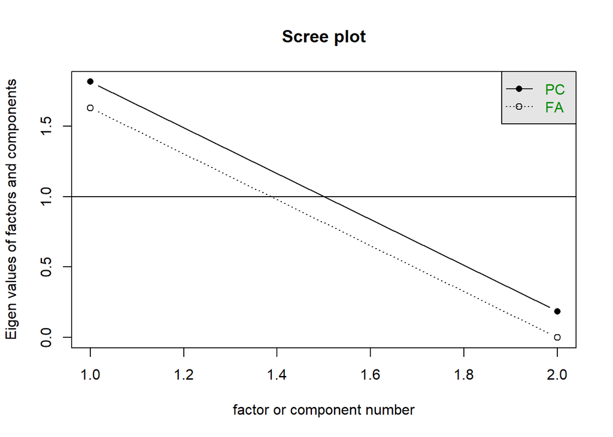

```r
# 요인수 결정
Gangwon <- final[final$spot=="Gangwon",c(3,6)]
Gangwon_cor <- cor(Gangwon, use = "pairwise.complete.obs")
scree(Gangwon_cor, factors = TRUE)
```